# Transformación de datos II / Manejo de datos

Fernando Pardo

## ¿Qué aprendimos la clase pasada?

- Utilizamos R para saber si comparaciones entre dos cantidades son ciertas o no (5 > 6 #FALSE, 6 == 6 #TRUE)
- Aprendimos el uso de los operadores y (&), o (|) y no (!): (5 > 6) | (3 < 4) #TRUE
- Aprendimos las funciones básicas para manipular **tablas de datos** (paquete **dplyr** contenido en el tidyverse):

| Funcionalidad | Función | Interpretación |
| --- | --- | --- |
| Seleccionar campos | select(diamonds, carat, cut) | Del data frame diamonds **seleccióname los campos** carat y cut |
| Seleccionar registros de acuerdo a un criterio | filter(diamonds, cut == “Ideal” \| x > 4) | Del data frame diamonds **seleccióname los registros (filter)** que cumplen “cut ==”Ideal" o (\|) “x > 4” |
| Ordenar registros de acuerdo a uno o más campos | arrange(diamonds, carat, depth) | Del data frame diamonds **ordéname los registros** primero por carat y luego, los que tengan valores iguales, por depth |
| Crear nuevas variables | mutate(diamonds, dollars_per_carat = price / carat) | Usando el data frame diamonds **créame la nueva columna** dollars_per_carat definida como price / carat |
| Preparar un data frame para calcular resúmenes por grupo | diamonds_agrupado <- group_by(diamonds, cut) | Usando el data frame diamonds, **prepárame los datos** para calcular resúmenes por valor de la columna cut, y **asigna** el resultado a la variable diamonds_agrupado |
| Calcular resúmenes por grupo | summarise(diamonds_agrupado, promedio_depth = mean(depth)) | Usando diamonds agrupado, **calcúlame el resumen** llamado promedio depth definido como la media de depth |

En esta clase aprenderemos a:

- Utilizar el operador **pipeline** para simplificar la aplicación de funciones de transformación de datos, una tras otra (recordar la tarea, ejercicio 3).
- Miscelánea de funcionalidades avanzadas de transformación de datos:
  - **joins** (uniones de dos o más tablas).
  - El paquete **tidyr** para transformar la **estructura** de los datos en una tabla.
- Un poco acerca de tipos de datos y datos faltantes (celdas vacías).
- Leer datos de CSV en R.

## El operador pipeline %>%

El ejercicio 3 de la tarea nos introduce a lo tedioso que es aplicar varias funciones para transformar datos una tras otra sin ayuda. Aquí es cuando el operador pipeline entra en acción:

Nos permite encadenar operaciones de manera sencilla, comenzando por el data frame original (diamonds), luego aplicar una transformación, al resultado aplicar otra y así sucesivamente.

Retomemos el ejemplo de la tarea 3. En lugar de:

```r
diamonds_dollars_per_carat <- mutate(diamonds, dollars_per_carat = price / carat)
diamonds_dollars_per_carat
```

```
## # A tibble: 53,940 x 11
##    carat       cut color clarity depth table price     x     y     z
##    <dbl>     <ord> <ord>   <ord> <dbl> <dbl> <int> <dbl> <dbl> <dbl>
##  1  0.23     Ideal     E     SI2  61.5    55   326  3.95  3.98  2.43
##  2  0.21   Premium     E     SI1  59.8    61   326  3.89  3.84  2.31
##  3  0.23      Good     E     VS1  56.9    65   327  4.05  4.07  2.31
##  4  0.29   Premium     I     VS2  62.4    58   334  4.20  4.23  2.63
##  5  0.31      Good     J     SI2  63.3    58   335  4.34  4.35  2.75
##  6  0.24 Very Good     J    VVS2  62.8    57   336  3.94  3.96  2.48
##  7  0.24 Very Good     I    VVS1  62.3    57   336  3.95  3.98  2.47
##  8  0.26 Very Good     H     SI1  61.9    55   337  4.07  4.11  2.53
##  9  0.22      Fair     E     VS2  65.1    61   337  3.87  3.78  2.49
## 10  0.23 Very Good     H     VS1  59.4    61   338  4.00  4.05  2.39
## # ... with 53,930 more rows, and 1 more variables: dollars_per_carat <dbl>
```

```r
diamonds_dollars_per_carat_filtrado <- filter(diamonds_dollars_per_carat, dollars_per_carat < 4000)
diamonds_dollars_per_carat_filtrado
```

```
## # A tibble: 32,083 x 11
##    carat       cut color clarity depth table price     x     y     z
##    <dbl>     <ord> <ord>   <ord> <dbl> <dbl> <int> <dbl> <dbl> <dbl>
##  1  0.23     Ideal     E     SI2  61.5    55   326  3.95  3.98  2.43
##  2  0.21   Premium     E     SI1  59.8    61   326  3.89  3.84  2.31
##  3  0.23      Good     E     VS1  56.9    65   327  4.05  4.07  2.31
##  4  0.29   Premium     I     VS2  62.4    58   334  4.20  4.23  2.63
##  5  0.31      Good     J     SI2  63.3    58   335  4.34  4.35  2.75
##  6  0.24 Very Good     J    VVS2  62.8    57   336  3.94  3.96  2.48
##  7  0.24 Very Good     I    VVS1  62.3    57   336  3.95  3.98  2.47
##  8  0.26 Very Good     H     SI1  61.9    55   337  4.07  4.11  2.53
##  9  0.22      Fair     E     VS2  65.1    61   337  3.87  3.78  2.49
## 10  0.23 Very Good     H     VS1  59.4    61   338  4.00  4.05  2.39
## # ... with 32,073 more rows, and 1 more variables: dollars_per_carat <dbl>
```

```r
diamonds_dollars_per_carat_filtrado_ordenado <- arrange(diamonds_dollars_per_carat_filtrado, desc(dollars_per_carat))
diamonds_dollars_per_carat_filtrado_ordenado
```

```
## # A tibble: 32,083 x 11
##    carat       cut color clarity depth table price     x     y     z
##    <dbl>     <ord> <ord>   <ord> <dbl> <dbl> <int> <dbl> <dbl> <dbl>
##  1  1.05 Very Good     J     SI1  62.5    58  4199  6.47  6.52  4.06
##  2  0.92 Very Good     E     SI2  63.2    54  3679  6.29  6.25  3.96
##  3  0.92   Premium     E     SI2  61.8    59  3679  6.19  6.11  3.80
##  4  0.91   Premium     E     SI2  61.1    59  3639  6.24  6.20  3.80
##  5  0.91   Premium     E     SI2  62.8    61  3639  6.09  6.07  3.82
##  6  0.90   Premium     E     SI2  62.6    60  3599  6.18  6.09  3.84
##  7  0.90   Premium     E     SI2  62.2    60  3599  6.19  6.15  3.84
##  8  0.90     Ideal     E     SI2  62.0    55  3599  6.23  6.15  3.84
##  9  1.51   Premium     H      I1  61.9    58  6038  7.39  7.34  4.56
## 10  0.74      Fair     G    VVS2  65.2    58  2959  5.70  5.60  3.69
## # ... with 32,073 more rows, and 1 more variables: dollars_per_carat <dbl>
```

El ejemplo de la tarea 3 queda:

```r
diamonds %>% # Comenzando con el df diamonds:
  mutate(dollars_per_carat = price / carat) %>% # Calcúlame la variable dollars per carat ... LUEGO
  filter(dollars_per_carat < 4000) %>% # Seleccióname los registros en que la variable dollars_per_carat < 4000 LUEGO
  arrange(desc(dollars_per_carat)) # Ordéname en orden descendente por la variable dollars per carat
```

```
## # A tibble: 32,083 x 11
##    carat       cut color clarity depth table price     x     y     z
##    <dbl>     <ord> <ord>   <ord> <dbl> <dbl> <int> <dbl> <dbl> <dbl>
##  1  1.05 Very Good     J     SI1  62.5    58  4199  6.47  6.52  4.06
##  2  0.92 Very Good     E     SI2  63.2    54  3679  6.29  6.25  3.96
##  3  0.92   Premium     E     SI2  61.8    59  3679  6.19  6.11  3.80
##  4  0.91   Premium     E     SI2  61.1    59  3639  6.24  6.20  3.80
##  5  0.91   Premium     E     SI2  62.8    61  3639  6.09  6.07  3.82
##  6  0.90   Premium     E     SI2  62.6    60  3599  6.18  6.09  3.84
##  7  0.90   Premium     E     SI2  62.2    60  3599  6.19  6.15  3.84
##  8  0.90     Ideal     E     SI2  62.0    55  3599  6.23  6.15  3.84
##  9  1.51   Premium     H      I1  61.9    58  6038  7.39  7.34  4.56
## 10  0.74      Fair     G    VVS2  65.2    58  2959  5.70  5.60  3.69
## # ... with 32,073 more rows, and 1 more variables: dollars_per_carat <dbl>
```

Podemos también asignar el resultado de TODAS las transformaciones anteriores a una variable

```r
diamonds_transformado_1 <- diamonds %>%
  mutate(dollars_per_carat = price / carat) %>%
  filter(dollars_per_carat < 4000) %>%
  arrange(desc(dollars_per_carat))
diamonds_transformado_1
```

```
## # A tibble: 32,083 x 11
##    carat       cut color clarity depth table price     x     y     z
##    <dbl>     <ord> <ord>   <ord> <dbl> <dbl> <int> <dbl> <dbl> <dbl>
##  1  1.05 Very Good     J     SI1  62.5    58  4199  6.47  6.52  4.06
##  2  0.92 Very Good     E     SI2  63.2    54  3679  6.29  6.25  3.96
##  3  0.92   Premium     E     SI2  61.8    59  3679  6.19  6.11  3.80
##  4  0.91   Premium     E     SI2  61.1    59  3639  6.24  6.20  3.80
##  5  0.91   Premium     E     SI2  62.8    61  3639  6.09  6.07  3.82
##  6  0.90   Premium     E     SI2  62.6    60  3599  6.18  6.09  3.84
##  7  0.90   Premium     E     SI2  62.2    60  3599  6.19  6.15  3.84
##  8  0.90     Ideal     E     SI2  62.0    55  3599  6.23  6.15  3.84
##  9  1.51   Premium     H      I1  61.9    58  6038  7.39  7.34  4.56
## 10  0.74      Fair     G    VVS2  65.2    58  2959  5.70  5.60  3.69
## # ... with 32,073 more rows, and 1 more variables: dollars_per_carat <dbl>
```

Otro ejemplo:

- Por combinación de cut y color,
- Calcular el mínimo de x, y también el máximo de y.
- Al resultado ordenarlo por color de manera descendente.

```r
diamonds_transformado_2 <- diamonds %>%
  # Primero agrupo por combinación de cut y color, ya que lo necesito para calcular
  # los resúmenes por grupo
  group_by(cut, color) %>%
  # Luego calculo los resúmenes por grupo
  summarise(minimo_x = min(x), maximo_y = max(y)) %>%
  # Finalmente ordeno por color
  arrange(desc(color))
diamonds_transformado_2
```

```
## # A tibble: 35 x 4
## # Groups:   cut [5]
##          cut color minimo_x maximo_y
##        <ord> <ord>    <dbl>    <dbl>
##  1      Fair     J     4.24    10.54
##  2      Good     J     4.22     9.19
##  3 Very Good     J     3.94     8.93
##  4   Premium     J     4.22     9.94
##  5     Ideal     J     3.93     9.20
##  6      Fair     I     4.62     9.02
##  7      Good     I     4.19     9.31
##  8 Very Good     I     3.95     9.94
##  9   Premium     I     3.97    10.10
## 10     Ideal     I     3.94     9.42
## # ... with 25 more rows
```

Transforma el código de todos los ejemplos de la sección 5 para incorporar el uso del pipeline.

## Miscelánea de funcionalidades avanzadas de transformación de datos

Con **dplyr**:

1. Realizar **joins** entre dos tablas.

Con **tidyr**:

2. **Gather**: transformar campos en registros
3. **Spread**: transformar registros en campos
4. **Separate**: separar variables

### 1. Joins: inner_join(df1, df2, columnas_a_seleccionar)

Es común encontrarse tablas que hacer referencia la una a la otra, por ejemplo:

Tipos de caracter

| id | tipo |
| --- | --- |
| 1 | letra |
| 2 | número |
| 3 | caracter especial |

Caracteres

| id | caracter | tipo_caracter_id |
| --- | --- | --- |
| 1 | a | 1 |
| 2 | 2 | 2 |
| 3 | 3 | 2 |
| 4 | 1 | 2 |
| 5 | z | 1 |
| 6 | 5 | 2 |
| 7 | m | 1 |
| 8 | 7 | 2 |
| 9 | s | 1 |
| 10 | x | 1 |

Para asociar a cada caracter su tipo, podemos utilizar una funcionalidad llamada **join**, que básicamente asocia registros de dos tablas usando campos en común.

```r
# Definiendo las tablas anteriores (normalmente estas tablas se leerán de archivos
# CSV o bases de datos como se verá la siguiente clase).

tipos_caracter <- data_frame(
  id = c(1, 2, 3),
  tipo = c("letra", "número", "caracter especial")
)
tipos_caracter
```

```
## # A tibble: 3 x 2
##      id              tipo
##   <dbl>             <chr>
## 1     1             letra
## 2     2            número
## 3     3 caracter especial
```

```r
caracteres <- data_frame(
  id = 1:10,
  caracter = c("a", "2", "3", "1", "z", "5", "m", "7", "s", "x"),
  tipo_caracter_id = c(1, 2, 2, 2, 1, 2, 1, 2, 1, 1)
)
caracteres
```

```
## # A tibble: 10 x 3
##       id caracter tipo_caracter_id
##    <int>    <chr>            <dbl>
##  1     1        a                1
##  2     2        2                2
##  3     3        3                2
##  4     4        1                2
##  5     5        z                1
##  6     6        5                2
##  7     7        m                1
##  8     8        7                2
##  9     9        s                1
## 10    10        x                1
```

```r
# Haciendo el join de las tablas anteriores
inner_join(caracteres, tipos_caracter, by = c("tipo_caracter_id" = "id"))
```

```
## # A tibble: 10 x 4
##       id caracter tipo_caracter_id   tipo
##    <int>    <chr>            <dbl>  <chr>
##  1     1        a                1  letra
##  2     2        2                2 número
##  3     3        3                2 número
##  4     4        1                2 número
##  5     5        z                1  letra
##  6     6        5                2 número
##  7     7        m                1  letra
##  8     8        7                2 número
##  9     9        s                1  letra
## 10    10        x                1  letra
```

```r
# Notemos que el orden importa para renombrar y ordenarlas columnas
inner_join(tipos_caracter, caracteres, by = c("id" = "tipo_caracter_id"))
```

```
## # A tibble: 10 x 4
##       id   tipo  id.y caracter
##    <dbl>  <chr> <int>    <chr>
##  1     1  letra     1        a
##  2     1  letra     5        z
##  3     1  letra     7        m
##  4     1  letra     9        s
##  5     1  letra    10        x
##  6     2 número     2        2
##  7     2 número     3        3
##  8     2 número     4        1
##  9     2 número     6        5
## 10     2 número     8        7
```

```r
# Existen muchos tipos de joins, y también joins por más de un campo. Para ver
# estas opciones consultar la ayuda de R: ?inner_join.
```

Expresa el join anterior usando el pipeline.

Evalúa las siguientes expresiones y explica con tus palabras el resultado.

```r
left_join(tipos_caracter, caracteres, by = c("id" = "tipo_caracter_id"))
semi_join(tipos_caracter, caracteres, by = c("id" = "tipo_caracter_id"))
anti_join(tipos_caracter, caracteres, by = c("id" = "tipo_caracter_id"))
```

### 2. Usar gather para transformar campos de un data frame en registros

Al transformar campos en registros, se quitan columnas y se agregan renglones al data frame. Esto se llama datos **largos**.

Ejemplo:

Pacientes por enfermedad el día 7 de julio 2017

| Hospital | Enfermedad_a | Enfermedad_b | Enfermedad_c |
| --- | --- | --- | --- |
| Siglo XXI | 7 | 10 | 5 |
| La Raza | 10 | 6 | 6 |
| Xoco | 8 | 4 | 3 |

Ahora, para cada registro, transformar sus campos “enfermedad a/b/c” en registros adicionales. Es decir, para:

1. El Siglo XXI, transformar los campos 7, 10, 5 en registros
2. La Raza, transformar los campos 10, 6, 6 en registros
3. Xoco, transformar los campos 8, 4, 3 en registros

Primera idea:

Pacientes por enfermedad para cada hospital, día 7 de julio 2017

| Hospital | Numero_pacientes |
| --- | --- |
| Siglo XXI | 7 |
| Siglo XXI | 10 |
| Siglo XXI | 5 |
| La Raza | 10 |
| La Raza | 6 |
| La Raza | 6 |
| Xoco | 8 |
| Xoco | 4 |
| Xoco | 3 |

¿Qué hay de malo con la primera idea?

Propón una solución al problema anterior

Para solucionar los problemas anteriores surge la función **gather**, la cuál funciona justo como esperamos:

```r
# Definiendo la tabla anterior:
pacientes_enfermedad <- data_frame(
  hospital = c(
    "Siglo XXI",
    "La Raza",
    "Xoco"
  ),
  enfermedad_a = c(
    7,
    10,
    8
  ),
  enfermedad_b = c(
    10,
    6,
    4
  ),
  enfermedad_c = c(
    5,
    6,
    3
  )
)
pacientes_enfermedad
```

```
## # A tibble: 3 x 4
##    hospital enfermedad_a enfermedad_b enfermedad_c
##       <chr>        <dbl>        <dbl>        <dbl>
## 1 Siglo XXI            7           10            5
## 2   La Raza           10            6            6
## 3      Xoco            8            4            3
```

```r
# Usando la función gather para transformar campos en registros:
# key: nombre de la columna con los nombres de los campos (ahora registros)
# value: nombre de la columna con los valores de los campos (numero_pacientes)
# lo que sigue son las columnas que definen los campos que se transformarán en renglones
pacientes_enfermedad_largos <- gather(pacientes_enfermedad, key = "enfermedad", value = "numero_pacientes", enfermedad_a, enfermedad_b, enfermedad_c)
pacientes_enfermedad_largos
```

```
## # A tibble: 9 x 3
##    hospital   enfermedad numero_pacientes
##       <chr>        <chr>            <dbl>
## 1 Siglo XXI enfermedad_a                7
## 2   La Raza enfermedad_a               10
## 3      Xoco enfermedad_a                8
## 4 Siglo XXI enfermedad_b               10
## 5   La Raza enfermedad_b                6
## 6      Xoco enfermedad_b                4
## 7 Siglo XXI enfermedad_c                5
## 8   La Raza enfermedad_c                6
## 9      Xoco enfermedad_c                3
```

### 2. Usar spread para transformar registros de un data frame en campos.

Al transformar registros en campos, se quitan renglones y se agregan columnas, lo que se llama datos **anchos**.

Es importante notar que gather y spread son funciones inversas, por lo que podemos usar spread para transformar nuestros datos largos a su forma original:

```r
# Viendo el data frame a expandir (spread). En este caso tenemos la columna
# de nombres de enfermedades (enfermedad), que se puede considerar como los nombres
# de nuestros campos, y numero_pacientes que se puede considerar como el valor
# de cada hospital en dichos campos:
pacientes_enfermedad_largos
```

```
## # A tibble: 9 x 3
##    hospital   enfermedad numero_pacientes
##       <chr>        <chr>            <dbl>
## 1 Siglo XXI enfermedad_a                7
## 2   La Raza enfermedad_a               10
## 3      Xoco enfermedad_a                8
## 4 Siglo XXI enfermedad_b               10
## 5   La Raza enfermedad_b                6
## 6      Xoco enfermedad_b                4
## 7 Siglo XXI enfermedad_c                5
## 8   La Raza enfermedad_c                6
## 9      Xoco enfermedad_c                3
```

```r
# Usando la función spread para transformar registros en campos:
# key: variable cuyos valores definirán los nombres de nuestros campos. Para
# revertir el data frame usaremos "enfermedad"
# value: variable que llenará los nuevos campos.
pacientes_enfermedad_anchos <- spread(pacientes_enfermedad_largos, key = enfermedad, value = numero_pacientes)
pacientes_enfermedad_anchos
```

```
## # A tibble: 3 x 4
##    hospital enfermedad_a enfermedad_b enfermedad_c
## *     <chr>        <dbl>        <dbl>        <dbl>
## 1   La Raza           10            6            6
## 2 Siglo XXI            7           10            5
## 3      Xoco            8            4            3
```

```r
# Es interesante comparar con nuesro data frame inicial
pacientes_enfermedad
```

```
## # A tibble: 3 x 4
##    hospital enfermedad_a enfermedad_b enfermedad_c
##       <chr>        <dbl>        <dbl>        <dbl>
## 1 Siglo XXI            7           10            5
## 2   La Raza           10            6            6
## 3      Xoco            8            4            3
```

A partir de “pacientes_enfermedad”, crea el siguiente data frame:

Pacientes por hospital para cada enfermedad, día 7 de julio del 2017

| enfermedad | La Raza | Siglo XXI | Xoco |
| --- | --- | --- | --- |
| enfermedad_a | 10 | 7 | 8 |
| enfermedad_b | 6 | 10 | 4 |
| enfermedad_c | 6 | 5 | 3 |

**Sugerencia**: Usa gather y luego spread. Puede usar el pipeline para simplificar.

### 3. Separar una columna en dos o más: separate(df, col = columna, into = c(nueva_variable_1, nueva_variable_2, etc)

Separate es una función útil para separar una columna de un data frame en varias columnas, cuyos nombres se especifican. La separación default se realiza por caracteres especiales (., _, espacios, etc). Por ejemplo:

```r
instructores_curso_r <- data_frame(
  id = c(1,2,3),
  nombre = c(
    "Fernando Pardo",
    "Teresa Ortiz",
    "Julian_Equihua"
  )
)
instructores_curso_r
```

```
## # A tibble: 3 x 2
##      id         nombre
##   <dbl>          <chr>
## 1     1 Fernando Pardo
## 2     2   Teresa Ortiz
## 3     3 Julian_Equihua
```

```r
separate(instructores_curso_r, nombre, into = c("nombre", "apellido_1"))
```

```
## # A tibble: 3 x 3
##      id   nombre apellido_1
## * <dbl>    <chr>      <chr>
## 1     1 Fernando      Pardo
## 2     2   Teresa      Ortiz
## 3     3   Julian    Equihua
```

Evalúa las siguientes expresiones, y explica con tus palabras lo que sucede

```r
instructores_curso_r_1 <- data_frame(
  id = c(1,2,3),
  nombre = c(
    "Fernando Pardo Urrutia",
    "Teresa Ortiz",
    "Julian_Equihua"
  )
)

separate(instructores_curso_r_1, nombre, into = c("nombre", "apellido_1"))
separate(instructores_curso_r_1, nombre, into = c("nombre", "apellido_1", "apellido_2"))
```

Da una explicación intuitiva de lo que es el **NA**

## Datos faltantes

Un **NA** es un dato faltante, es decir, un vacío en una tabla. Como en R los data frames contienen un elemento en cada campo, estos vacíos se traducen como datos faltantes.

**Como son vacíos de información, los datos faltantes se pueden pensar como “no se”**

```r
NA # Dato Faltante
```

```
## [1] NA
```

```r
NA + 3 # No se + 3 = No se
```

```
## [1] NA
```

```r
NA * 3 # No se * 3 = No se
```

```
## [1] NA
```

```r
is.na(NA) # Un operador binario para preguntar si un dato es faltante (NA)
```

```
## [1] TRUE
```

```r
is.na(5.3)
```

```
## [1] FALSE
```

```r
is.na(FALSE)
```

```
## [1] FALSE
```

```r
FALSE | NA # No se cuánto da FALSE ó NA
```

```
## [1] NA
```

```r
TRUE | NA # Pero TRUE o NA sí, porque sabemos que verdadero ó lo que sea ya es verdadero: como (5 > 3) | (1 > 3)
```

```
## [1] TRUE
```

```r
NA > 5 # ¿Es NO SE > 5? NO SE
```

```
## [1] NA
```

```r
NA == NA #¿Es NO SE igual a NO SE? NO SE
```

```
## [1] NA
```

```r
sum(c(4, 5, 6, NA)) # No se cuanto da la suma de algo 4, 5, 6, y no se.
```

```
## [1] NA
```

```r
sum(c(4, 5, 6, NA), na.rm = TRUE) # Pero puedo decirle a R que remueva los NA's
```

```
## [1] 15
```

```r
mean(c(4, 5, 6, NA), na.rm = TRUE)
```

```
## [1] 5
```

```r
# Dado un data frame con datos faltantes
registro <- data_frame(
  id = c(1, 2, 3),
  persona = c("Fernando", NA, "Julián"),
  numero_socio = c(13, 12, NA)
)
registro
```

```
## # A tibble: 3 x 3
##      id  persona numero_socio
##   <dbl>    <chr>        <dbl>
## 1     1 Fernando           13
## 2     2     <NA>           12
## 3     3   Julián           NA
```

```r
# Puedo seleccionar renglones con NA:
registro %>%
  filter(is.na(persona))
```

```
## # A tibble: 1 x 3
##      id persona numero_socio
##   <dbl>   <chr>        <dbl>
## 1     2    <NA>           12
```

```r
# O renglones sin NA:
registro %>%
  filter(!is.na(persona))
```

```
## # A tibble: 2 x 3
##      id  persona numero_socio
##   <dbl>    <chr>        <dbl>
## 1     1 Fernando           13
## 2     3   Julián           NA
```

```r
# Puedo usar las reglas anteriores para calcular nuevas columnas:
registro %>%
  mutate(numero_socio_nuevo = numero_socio + 1)
```

```
## # A tibble: 3 x 4
##      id  persona numero_socio numero_socio_nuevo
##   <dbl>    <chr>        <dbl>              <dbl>
## 1     1 Fernando           13                 14
## 2     2     <NA>           12                 13
## 3     3   Julián           NA                 NA
```

```r
# Puedo ordenar y los NA's quedan al final
registro %>%
  arrange(numero_socio)
```

```
## # A tibble: 3 x 3
##      id  persona numero_socio
##   <dbl>    <chr>        <dbl>
## 1     2     <NA>           12
## 2     1 Fernando           13
## 3     3   Julián           NA
```

```r
# Puedo ordenar y los NA's quedan al final
registro %>%
  arrange(desc(numero_socio))
```

```
## # A tibble: 3 x 3
##      id  persona numero_socio
##   <dbl>    <chr>        <dbl>
## 1     1 Fernando           13
## 2     2     <NA>           12
## 3     3   Julián           NA
```

```r
# Tengo que tener cuidado con calcular resúmenes de data frames que contienen NA's
registro %>%
  summarise(promedio = mean(numero_socio))
```

```
## # A tibble: 1 x 1
##   promedio
##      <dbl>
## 1       NA
```

```r
# Pero puedo arreglarlo fácilmente
registro %>%
  summarise(promedio = mean(numero_socio, na.rm = TRUE))
```

```
## # A tibble: 1 x 1
##   promedio
##      <dbl>
## 1     12.5
```

## Tipos de datos en R

Como ya sabemos intuitivamente, R maneja diversos tipos de datos, entre los más comunes se encuentran:

1. **Enteros** Que en particular son de clase **numérico**
2. **Caracter**: Los strings (que se escriben entre comillas)
3. **Lógicos**: TRUE, FALSE, NA
4. **Factores**: Básicamente strings que se codifican de esta manera para poder correr modelos.
5. **Fechas**

Podemos preguntar acerca de estas clases en R

```r
# Se puede preguntar por la clase de un objeto, que corresponde al tipo de datos
# en el caso de vectores o valores individuales (en realidad son vectores de longitud 1)
class(5)
```

```
## [1] "numeric"
```

```r
class(c(5.3, 2))
```

```
## [1] "numeric"
```

```r
class(TRUE)
```

```
## [1] "logical"
```

```r
class("este es un string")
```

```
## [1] "character"
```

```r
# Se puede revisar la clase de cada columna de un data frame con la función "glimpse"
glimpse(diamonds) # ord son factores ordenados, básicamente strings a los que
```

```
## Observations: 53,940
## Variables: 10
## $ carat   <dbl> 0.23, 0.21, 0.23, 0.29, 0.31, 0.24, 0.24, 0.26, 0.22, ...
## $ cut     <ord> Ideal, Premium, Good, Premium, Good, Very Good, Very G...
## $ color   <ord> E, E, E, I, J, J, I, H, E, H, J, J, F, J, E, E, I, J, ...
## $ clarity <ord> SI2, SI1, VS1, VS2, SI2, VVS2, VVS1, SI1, VS2, VS1, SI...
## $ depth   <dbl> 61.5, 59.8, 56.9, 62.4, 63.3, 62.8, 62.3, 61.9, 65.1, ...
## $ table   <dbl> 55, 61, 65, 58, 58, 57, 57, 55, 61, 61, 55, 56, 61, 54...
## $ price   <int> 326, 326, 327, 334, 335, 336, 336, 337, 337, 338, 339,...
## $ x       <dbl> 3.95, 3.89, 4.05, 4.20, 4.34, 3.94, 3.95, 4.07, 3.87, ...
## $ y       <dbl> 3.98, 3.84, 4.07, 4.23, 4.35, 3.96, 3.98, 4.11, 3.78, ...
## $ z       <dbl> 2.43, 2.31, 2.31, 2.63, 2.75, 2.48, 2.47, 2.53, 2.49, ...
```

```r
# se les asigna un orden.

# Se puede preguntar la clase de un objeto
is.integer(5.3)
```

```
## [1] FALSE
```

```r
is.logical(TRUE)
```

```
## [1] TRUE
```

```r
is.character(2)
```

```
## [1] FALSE
```

```r
is.factor("gato")
```

```
## [1] FALSE
```

```r
is.factor(as.factor("gato"))
```

```
## [1] TRUE
```

```r
# Se puede trabajar con fechas usando el paquete "lubridate"
library("lubridate")
is.Date("26/07/2017")
```

```
## [1] FALSE
```

```r
as.Date("26/07/2017") %>%
  is.Date()
```

```
## [1] TRUE
```

## Adelanto de la siguiente clase: lectura de datos de CSV en R

Para leer datos de CSV en R es conveniente seguir los siguientes pasos:

0. Guardar el script donde se está trabajando.
1. Establecer la carpeta que contiene nuestro script como la carpeta de referencia para encontrar nuestros datos (**Session > Set Working Directory > To Source File Location**)
2. Usar la función **read_csv** contenida en el paquete **readr** del tidyverse. A dicha función se le pasará la **ruta del archivo CSV** a partir de la carpeta donde se encuentra el script actual (se puede ir una carpeta atrás con ../).

Ejemplo:

```r
ataque_pokemon <- read_csv("datos/ataque_pokemon.csv")
ataque_pokemon
```

```
## # A tibble: 251 x 4
##       no       name attack special_attack
##    <int>      <chr>  <int>          <int>
##  1     1  bulbasaur     49             65
##  2     2    ivysaur     62             80
##  3     3   venusaur     82            100
##  4     4 charmander     52             60
##  5     5 charmeleon     64             80
##  6     6  charizard     84            109
##  7     7   squirtle     48             50
##  8     8  wartortle     63             65
##  9     9  blastoise     83             85
## 10    10   caterpie     30             20
## # ... with 241 more rows
```

**Tarea:** Explica con tus palabras cada comando utilizado para realizar la siguiente gráfica

```r
ataque_pokemon <- read_csv("datos/ataque_pokemon.csv")
glimpse(ataque_pokemon)
```

```
## Observations: 251
## Variables: 4
## $ no             <int> 1, 2, 3, 4, 5, 6, 7, 8, 9, 10, 11, 12, 13, 14, ...
## $ name           <chr> "bulbasaur", "ivysaur", "venusaur", "charmander...
## $ attack         <int> 49, 62, 82, 52, 64, 84, 48, 63, 83, 30, 20, 45,...
## $ special_attack <int> 65, 80, 100, 60, 80, 109, 50, 65, 85, 20, 25, 9...
```

```r
defensa_pokemon <- read_csv("datos/defensa_pokemon.csv")
glimpse(defensa_pokemon)
```

```
## Observations: 251
## Variables: 4
## $ no              <int> 1, 2, 3, 4, 5, 6, 7, 8, 9, 10, 11, 12, 13, 14,...
## $ name            <chr> "bulbasaur", "ivysaur", "venusaur", "charmande...
## $ defense         <int> 49, 63, 83, 43, 58, 78, 65, 80, 100, 35, 55, 5...
## $ special_defense <int> 65, 80, 100, 50, 65, 85, 64, 80, 105, 20, 25, ...
```

```r
velocidad_hp_pokemon <- read_csv("datos/velocidad_hp_pokemon.csv")
glimpse(velocidad_hp_pokemon)
```

```
## Observations: 251
## Variables: 3
## $ name  <chr> "bulbasaur", "ivysaur", "venusaur", "charmander", "charm...
## $ speed <int> 45, 60, 80, 65, 80, 100, 43, 58, 78, 45, 30, 70, 50, 35,...
## $ hp    <int> 45, 60, 80, 39, 58, 78, 44, 59, 79, 45, 50, 60, 40, 45, ...
```

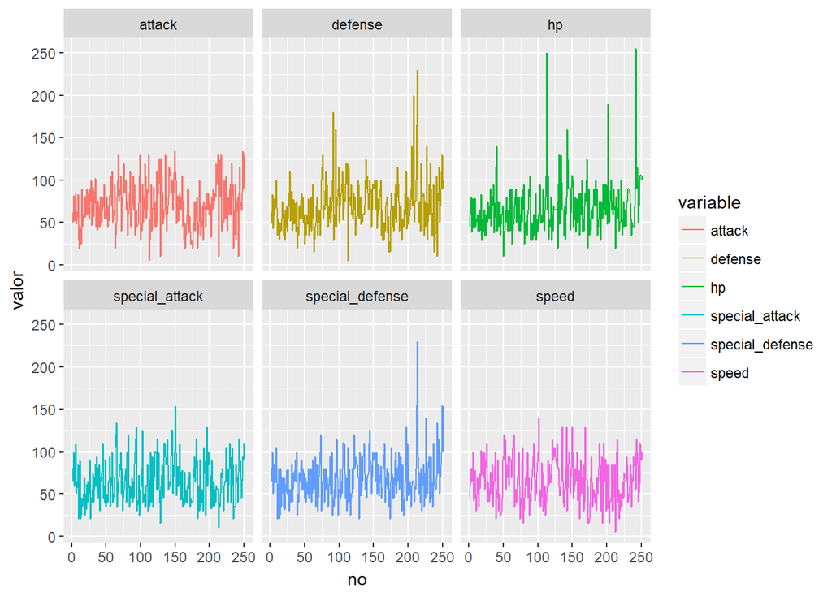

```r
datos_plot <- ataque_pokemon %>%
  inner_join(defensa_pokemon, by = c("no" = "no", "name" = "name")) %>%
  inner_join(velocidad_hp_pokemon, by = "name") %>%
  gather("variable", "valor", attack, special_attack, defense, special_defense, speed, hp)

ggplot(data = datos_plot, aes(x = no, y = valor, colour = variable)) +
  geom_line() +
  facet_wrap(~variable)
```

Estudia las notaciones de los inner joins (en el by) y explica con tus palabras a qué se deben las diferencias.

¿Por qué es crucial el gather para graficar? **Este es un buen tip: muchas veces se necesita pasar a datos largos para hacer una gráfica por grupos.**

Realiza la misma gráfica por tu cuenta, es decir, sin ver el código expuesto anteriormente.